# Final Project R Notebook

Phil Prosapio, Shayan Khan, Jiyuan Zhou

# Introduction to Data Set

For our final project, our group decided to tackle the Shelter Animal Outcomes Kaggle competition (found here: https://www.kaggle.com/c/shelter-animal-outcomes/data). This data comes from the Austin Animal Center from October 1st, 2013 to March, 2016. To supplement this Kaggle dataset, we went directly to the Austin Animal Center website and downloaded a related dataset that contains intake information about the pets and merged this additional info into our overall dataset (https://data.austintexas.gov/Health-and-Community-Services/Austin-Animal-Center-Intakes/wter-evkm).Fun fact is that one of our group members actually worked at this animal center back in Austin!

This dataset contains information about cats and dogs that were sheltered at the Austin Animal Center. It contains general info about the animals like: type of animal, breed, color, age on outcome, etc.; where the outcome of interest in this competition represent the status of animals as they leave the Animal Center. We needed to merge our intake and outcome datasets and some of the data columns required cleanup or transformation to be of more use to us (e.g. splitting the Sex column into the animals Sex as well as the status of their sexual organs - neutered/intact/etc.), while others were of no value when it comes to trying to apply our models. All animals receive a unique Animal ID during intake.

Our goal is to predict the outcome of animals as they leave the animal center. The outcomes can be one of the following: Adoption, Died, Euthanasia, Return to owner, and Transfer.

The train and test data were randomly split for us already.

It is our belief that producing an accurate and detailed model to help predict outcomes for these shelter animals could help the Austin Animal Center and the animals themselves in a couple ways: - Help the animal center better predict the outcome of a new animal that comes into the shelter. And depending on that predicted outcome, take proactive measures to steer “assist” the animal in receiving a better outcome based on what our model tells us makes for a pet that is more likely to be adopted. - Help the animal center better predict allocation of resources based on what actions might need to be taken for each pet in order to maximize the number of positive outcomes for the shelter animals.

## Project setup

```r
#Load Libraries
libraries <- c("tidyverse", "ggplot2", "DataExplorer", "gridExtra",
               "reshape", "purrr", "lubridate")
for(lb in libraries){
  # cat(paste(lb))
  if(!(require(lb, character.only = TRUE))){
    install.packages(lb)
  }
  library(lb, character.only = TRUE)
}
```

# #Helper Functions for Data Cleanup and EDA

```r
#Helper function to convert values in the AgeuponOutcome/Intake column from time strings (e.g. 1 year, 2 months, etc.) into time in months
timeWarp <- function(age) {
  age_elements <- str_split_fixed(age,"\\s",2)
  norm_age = as.numeric(age_elements[1])
  norm_age
  time_unit = age_elements[2]
  #Based on unit of time, appropriately scale up age variable
  if (grepl(time_unit, "(week)s?")) {
    norm_age = norm_age*7
  } else if (grepl(time_unit, "(months)s?")) {
    norm_age = norm_age*30
  } else if (grepl(time_unit, "(year)s?")) {
    norm_age = norm_age * 365
  }
  return(norm_age / 30)
}
```

## Exploratory Data Analysis of Data

Read in the data from the two different data sources we are using: the animal intake dataset and animal outtake dataset. We then apply the timeWarp function on both data sets to make their age columns into usable values.

```r
#Load in data and start transforming it
animal_out <- read_csv(gzfile("data/train.csv.gz")) %>%
              select(-DateTime, -OutcomeSubtype) %>%
              transform(SexuponOutcome = colsplit(SexuponOutcome, split = "\\s+", names = c('S_Organ_Status_Out', 'Sex_drop')))
animal_in <- read_csv("data/Austin_Animal_Center_Intakes.csv") %>%
             select(-Name, -Breed, -Color, -`Animal Type`) %>%
             transform(`Sex upon Intake` = colsplit(`Sex upon Intake`, split = "\\s+", names = c('S_Organ_Status_In', 'Sex')))
```

## Clean the data

Clean up and split a variety of columns to produce more usable features that can then be used in our models.

```r
animal_out$AgeuponOutcome <- vapply(animal_out$AgeuponOutcome, FUN = timeWarp, FUN.VALUE = double(1))
animal_in$AgeuponIntake <- vapply(animal_in$Age.upon.Intake, FUN = timeWarp, FUN.VALUE = double(1))
#Split the SexuponOutcome/Intake columns in order to get access to the pets sex as well as the status of their sexual organs (neutered, intact, etc.)
animal_out$S_Organ_Status_Out <- animal_out$SexuponOutcome$S_Organ_Status_Out
animal_out$Sex_drop <- animal_out$SexuponOutcome$Sex_drop
animal_in$S_Organ_Status_In <- animal_in$Sex.upon.Intake$S_Organ_Status_In
animal_in$Sex <- animal_in$Sex.upon.Intake$Sex
#Convert Name column into factor so we can see if the fact that the pet had a name documented affected it's outcome. 1=Had Name, 0=Name Unknown
animal_out$Name[!is.na(animal_out$Name)] <- 1
animal_out$Name[is.na(animal_out$Name)] <- 0
animal_out$Name <- as.factor(animal_out$Name)
#Final steps of cleaning up my data and then merging it together.
animal_out <- animal_out %>% #cad standing for Cleaned_Animal_Data
       select(-SexuponOutcome, -Sex_drop) %>%
       na.omit()
animal_in <- animal_in %>%
             select(-Sex.upon.Intake, -Age.upon.Intake)
#Inner join to combine data from the intake and outcome data frames and merge each row based on the unique Animal ID.
a_merged <- inner_join(animal_out, animal_in, by = c("AnimalID" = "Animal.ID"), all.x=TRUE) %>%
                   filter(AgeuponIntake <= AgeuponOutcome)
#Save off a non-dummified column for use in EDA
plot_data <- a_merged %>%
             select(-AnimalID)
```

```r
glimpse(a_merged)
```

```
Observations: 28,626
Variables: 16
$ AnimalID           <chr> "A671945", "A656520", "A686464", "A683430", "A667013", "A677334", "A699218", "A701489...
$ Name               <fct> 1, 1, 1, 0, 0, 1, 1, 0, 1, 0, 0, 0, 1, 1, 1, 1, 1, 0, 1, 1, 1, 1, 1, 1, 1, 1, 1, 1, 1...
$ OutcomeType        <chr> "Return_to_owner", "Euthanasia", "Adoption", "Transfer", "Transfer", "Transfer", "Tra...
$ AnimalType         <chr> "Dog", "Cat", "Dog", "Cat", "Dog", "Dog", "Cat", "Cat", "Dog", "Dog", "Cat", "Dog", "...
$ AgeuponOutcome     <dbl> 12.16666667, 12.16666667, 0.06666667, 0.10000000, 0.06666667, 1.00000000, 0.10000000,...
$ Breed              <chr> "Shetland Sheepdog Mix", "Domestic Shorthair Mix", "Pit Bull Mix", "Domestic Shorthai...
$ Color              <chr> "Brown/White", "Cream Tabby", "Blue/White", "Blue Cream", "Tan", "Black/Tan", "Blue T...
$ S_Organ_Status_Out <fct> Neutered, Spayed, Neutered, Intact, Neutered, Intact, Intact, Unknown, Spayed, Spayed...
$ DateTime           <chr> "2/2/2014 9:31", "10/13/2013 11:49", "8/22/2014 12:57", "7/10/2014 12:05", "11/11/201...
$ MonthYear          <chr> "2/2/2014 9:31", "10/13/2013 11:49", "8/22/2014 12:57", "7/10/2014 12:05", "11/11/201...
$ Found.Location     <chr> "1156 Cesar Chavez in Austin (TX)", "Austin (TX)", "Pearce Rd And City Park in Austin...
$ Intake.Type        <chr> "Stray", "Owner Surrender", "Stray", "Stray", "Stray", "Public Assist", "Stray", "Str...
$ Intake.Condition   <chr> "Normal", "Normal", "Normal", "Sick", "Normal", "Normal", "Nursing", "Nursing", "Norm...
$ AgeuponIntake      <dbl> 12.16666667, 12.16666667, 0.06666667, 0.10000000, 0.06666667, 1.00000000, 0.10000000,...
$ S_Organ_Status_In  <fct> Neutered, Spayed, Intact, Intact, Neutered, Intact, Intact, Unknown, Intact, Intact, ...
$ Sex                <fct> Male, Female, Male, Male, Male, Female, Male, Unknown, Female, Female, Unknown, Femal...
```

```r
length(unique(a_merged$Breed))
```

```
[1] 1367
```

## Feature Engineering

First we need to clean the dataset to move “mix” into its own feature and keep only the first breed mentioned for the breed mixes

```r
a_merged <- a_merged %>%
  mutate(mix = ifelse(grepl("mix", Breed, ignore.case = T), 1, 0),
         breed_new = gsub(" Mix", "", Breed),
         breed_new = strsplit(x = breed_new, split = "/"),
         breed_new = map_chr(breed_new, function(x){unlist(x[1])}))
```

Because there are so many separate breeds and colors, it would be difficult to includee them in our model. For this reason, we’ll categorize them for analysis.

```r
popular <- a_merged %>%
  count(breed_new, sort = TRUE) %>%
  mutate(freq = round(100 * n / sum(n),2)) %>%
  mutate(cumfreq = cumsum(freq)) %>%
  mutate(is_pop = ifelse(cumfreq < 75, 1, 0))
popular %>%
  head(20)
```

| breed_new | n | freq | cumfreq | is_pop |
| --- | --- | --- | --- | --- |
| Domestic Shorthair | 8968 | 31.33 | 31.33 | 1 |
| Pit Bull | 2470 | 8.63 | 39.96 | 1 |
| Chihuahua Shorthair | 2295 | 8.02 | 47.98 | 1 |
| Labrador Retriever | 2121 | 7.41 | 55.39 | 1 |
| German Shepherd | 954 | 3.33 | 58.72 | 1 |
| Domestic Medium Hair | 893 | 3.12 | 61.84 | 1 |
| Australian Cattle Dog | 565 | 1.97 | 63.81 | 1 |
| Domestic Longhair | 556 | 1.94 | 65.75 | 1 |
| Dachshund | 542 | 1.89 | 67.64 | 1 |
| Siamese | 441 | 1.54 | 69.18 | 1 |

[output cut: 10 more lines]

For dogs, the most common breeds are Pit Bulls, Chihuahuas, and Labs.

```r
dog_popular <- a_merged %>%
  filter(AnimalType == 'Dog') %>%
  count(breed_new, sort = TRUE) %>%
  mutate(freq = round(100 * n / sum(n),2)) %>%
  head(16)
print(dog_popular)
```

| breed_new | n | freq |
| --- | --- | --- |
| Pit Bull | 2470 | 14.15 |
| Chihuahua Shorthair | 2295 | 13.15 |
| Labrador Retriever | 2121 | 12.15 |
| German Shepherd | 954 | 5.47 |
| Australian Cattle Dog | 565 | 3.24 |
| Dachshund | 542 | 3.11 |
| Boxer | 395 | 2.26 |
| Border Collie | 381 | 2.18 |
| Miniature Poodle | 340 | 1.95 |
| Beagle | 263 | 1.51 |

[output cut: 6 more lines]

80% of Cat breeds appear to be Domestic Shorthair.

```r
cat_popular <- a_merged %>%
  filter(AnimalType == 'Cat') %>%
  count(breed_new, sort = TRUE) %>%
  mutate(freq = round(100 * n / sum(n),2)) %>%
  head(16)
print(cat_popular)
```

| breed_new | n | freq |
| --- | --- | --- |
| Domestic Shorthair | 8968 | 80.26 |
| Domestic Medium Hair | 893 | 7.99 |
| Domestic Longhair | 556 | 4.98 |
| Siamese | 441 | 3.95 |
| Snowshoe | 76 | 0.68 |
| Maine Coon | 46 | 0.41 |
| Manx | 45 | 0.40 |
| Russian Blue | 37 | 0.33 |
| Himalayan | 19 | 0.17 |
| Persian | 13 | 0.12 |

[output cut: 6 more lines]

```r
popular %>%
  filter(is_pop == 1) %>%
  select(breed_new) -> common
a_merged <- a_merged %>%
  mutate(breed_common = ifelse(breed_new %in% common$breed_new, 1, 0))
```

```r
breed_groups <- read.csv("breedGroups.csv")
names(breed_groups) <- c("breed_new", "breed_group")
#color_groups <- read.csv("colorGroups.csv", row.names = NULL)
a_merged <- inner_join(a_merged, breed_groups, by = "breed_new")
```

```
Column `breed_new` joining character vector and factor, coercing into character vector
```

```r
#a_merged <- left_join(a_merged, color_groups, by = c("Color" = "colors"))
```

# Save off data frame for use at later points

```r
write.csv(a_merged, file="Data/Cleaned_Data_Frame.csv")
```

# Graphical Analysis of Data for EDA

We first use DataExplorer’s plot_bar function to get an initial understanding of how our data’s variables are distributed.

```
7 columns ignored with more than 50 categories.
AnimalID: 25938 categories
Breed: 1366 categories
Color: 363 categories
DateTime: 21666 categories
MonthYear: 21666 categories
Found.Location: 14832 categories
breed_new: 218 categories
```

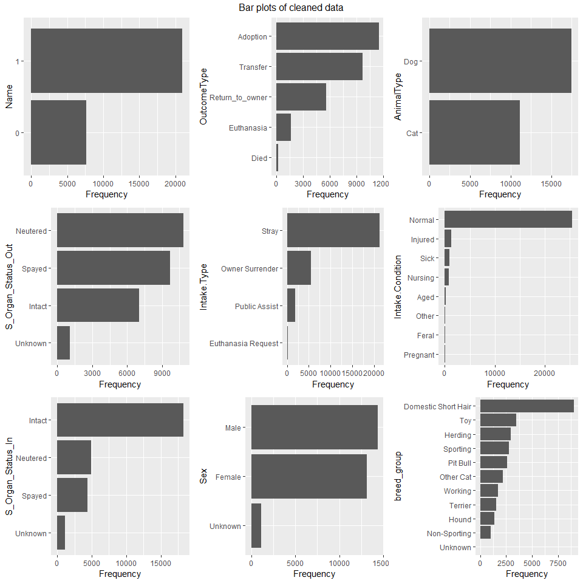

```r
a_merged %>%
    plot_bar(title = "Bar plots of cleaned data")
```

We then glimpse our two main data_sets (plot_data, which is used in our upcoming ggplot calls and a_merged, which is what we will be using for our modeling in the second half of this project)

```r
glimpse(plot_data)
```

[output not shown]

```r
glimpse(a_merged)
```

[output not shown]

# ggplots of various features to gain additional insight into our dataset

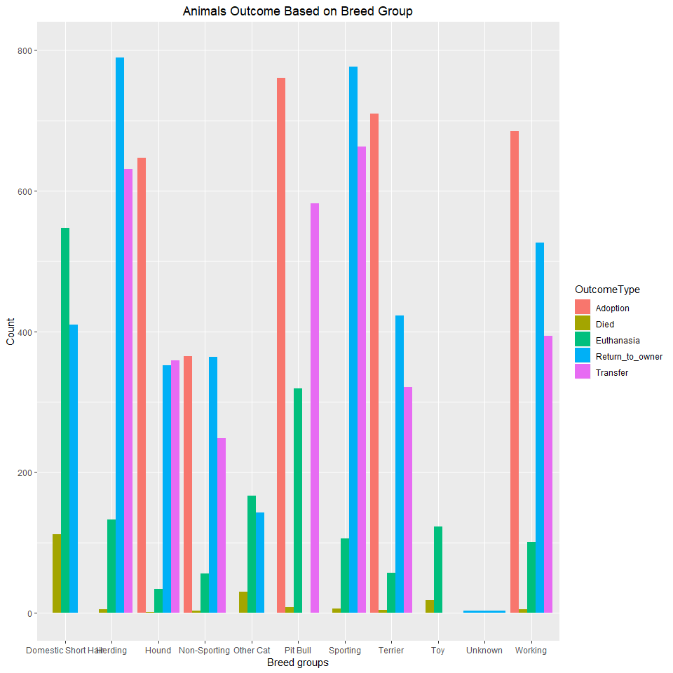

```r
#we need to use the a_merged dataset for this plot since it has the transformed breed_group variable
g <- ggplot(data=a_merged, aes(x=breed_group, fill= OutcomeType ))
g + geom_bar(stat="count", position=position_dodge()) +
    xlab("Breed groups") +
    ylab("Count") +
    ylim(0, 800) +
    ggtitle("Animals Outcome Based on Breed Group") +
    theme(plot.title = element_text(hjust = 0.5))
```

```r
g <- ggplot(data=plot_data, aes(x=AnimalType, fill= OutcomeType ))
g + geom_bar(stat="count", position=position_dodge()) +
    xlab("Whether a cat is over average heart weight") +
    ggtitle("Gender distributin on over and below average heart weight group.") +
    facet_grid(~ OutcomeType)
```

[output not shown]

```r
g <- ggplot(data=plot_data, aes(x=Name, fill= OutcomeType ))
g + geom_bar(stat="count", position=position_dodge()) +
    xlab("Whether a cat is over average heart weight") +
    ggtitle("Gender distributin on over and below average heart weight group.") +
    facet_grid(~ OutcomeType)
```

[output not shown]

```r
g <- ggplot(data=plot_data, aes(x=S_Organ_Status_Out, fill= OutcomeType ))
g + geom_bar(stat="count", position=position_dodge()) +
    xlab("Whether a cat is over average heart weight") +
    ggtitle("Gender distributin on over and below average heart weight group.") +
    facet_grid(~ OutcomeType)
```

[output not shown]

```r
g <- ggplot(data=plot_data, aes(x=AgeuponOutcome, fill= OutcomeType ))
g + geom_bar(stat="bin", position=position_dodge()) +
    xlab("Whether a cat is over average heart weight") +
    ggtitle("Gender distributin on over and below average heart weight group.") +
    facet_grid(~ OutcomeType)
```

[output not shown]